# Cómo ganar al League of Legends

Assingment Brief de la asignatura Machine Learning

Carlos Fisac Ferrández

MSMK University

May 17th, 2023

Abstract

Análisis en R de qué variables son más importantes a la hora de ganar una partida del aclamado título de *Riot Games*.

# Introducción

*League of Legends* es un juego multijugador de arena de batalla en línea (*MOBA*), desarrollado y publicado por *Riot Games* en 2009. En cada partida, dos equipos de cinco integrantes cada uno, lucharán por derribar el “Nexo” enemigo, el cual es una estructura colocada en el lado opuesto de donde comienza cada equipo. En el modo clásico, cada uno de los integrantes controlará un personaje distinto denominado “campeón”, con un set de habilidades único y diferentes estilos de juego.

El anterior mencionado “Nexo” está protegido por distintas estructuras y “súbditos”, unos enemigos que aparecen periódicamente desde cada lado del mapa para ayudar a los “campeones” en su propósito de abrirse paso hacia la base enemiga. Esos súbditos dan “oro” y “experiencia”, lo cual es necesario para mejorar a tu “campeón” a base de objetos (que se compran con “oro”) y “niveles” (los cuales mejoran tus “habilidades”).

La arena se conoce como “La Grieta del Invocador” y toma esta estructura (simplificada):

- Hay 3 “líneas” o calles: por ellas caminarán los “súbditos” y están protegidas por 3 “torres” por cada equipo en cada calle antes de llegar a la “base” rival. Las “líneas” son *Top, Mid* y *Bot.*
- El resto del mapa que no es ni una “base” ni una “calle” (en verde oscuro en la imagen) se conoce como “jungla”, en la cual hay monstruos neutrales (los cuales se comportan como los “súbditos” mencionados anteriormente) y objetivos importantes para acabar la partida como los “Dragones”, “Heraldos” y “Barón Nashor”. Estos objetivos proporcionan mejoras al equipo que los reclame.

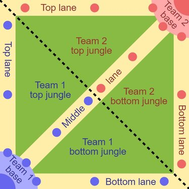

Grieta del Invocador (simplificada)

[Original PNG version by Raizin, SVG rework by Sameboat](https://commons.wikimedia.org/w/index.php?curid=29443207)

Los “campeones” por defecto no pueden ver todas las zonas del mapa (y algunos “campeones” basan su identidad en no ser vistos, p. ej. *Shaco* o *Evelynn*), por lo que es necesario comprar “guardianes de visión” para colocar en las zonas de “jungla” y posteriormente en las zonas del mapa derribadas durante el transcurso de la partida.

La mayoría de los eventos generan “oro”, p. ej., la primera baja que suceda en la partida (*first Blood*) da 400 de “oro” al “campeón” que la reclame, una baja habitual da 300, romper una torre da 50 de oro a cada miembro del equipo y 100 al que la tire, un tótem da 20, etcétera.

En *League of Legends* es posible rendirse si al menos 4/5 de los integrantes del equipo están dispuestos a ello en el minuto 20 de partida, existiendo una ocasión extraordinaria a los 15 minutos si dicha rendición es **unánime.**

Este título se ha coronado como uno de los videjuegos con más jugadores concurrentes, con una cifra de [152 millones](https://activeplayer.io/league-of-legends/) de jugadores a día de hoy. Estas cifras han hecho que este juego tenga mucha actividad a su alrededor, y mucha actividad económica se haya desarrollado en su ecosistema, como merchandising no-oficial, o aplicaciones de terceros.

[*Mobalytics*](https://mobalytics.gg/) es una empresa que desarrolla *software* a modo de *overlay* (*software* que se ejecuta mientras juegas para añadirte información) sobre distintos títulos de *Riot Games*, incluido el *League of Legends*. Esta empresa recopila datos sobre sus usuarios y el desempeño en sus partidas de cara a proporcionar mejores guías e indicadores para que sus usuarios puedan mejorar en el videojuego.

Este *overlay* necesita conocer qué datos son más determinantes de cara a predecir si la partida se puede ganar o no, de cara a mostrar a sus usuarios si votar rendirse porque la partida está **inevitablemente perdida**, o si por el contrario todavía hay un tanto por ciento suficiente de posibilidades de victoria como para que merezca la pena seguir jugando.

# Descripción del problema

Con esta introducción simplificada del funcionamiento del videojuego, se ilustra que existen muchas variables que dan ventaja a un equipo u otro. Aunque el objetivo final sea inequívoco para ganar la partida (derribar el nexo enemigo), hay muchas otras variables no tan directas como “Nexo destruido: Sí o No” que hay que tener en cuenta para dictaminar *a priori* qué va a pasar en los minutos siguientes, y poder predecir qué resultado va a tener la partida antes de derribar el nexo.

La amplia popularidad de este videjouego hace que sea muy factible extraer datos de este, ya que dispone de API pública, por lo que tendremos a disposición las variables cualesquiera que necesitemos. El objetivo en este informe es escoger un modelo de *machine learning* que prediga qué equipo va a ganar una partida en función de qué haya sucedido en la misma, asimismo como decidir cuáles son las variables más determinantes en dicho modelo.

# Análisis en R

## Datos de origen

En principio se pretendía obtener datos reales al acceder a la [API Oficial](https://developer.riotgames.com/) de Riot Games, pero se demora entre 2 y 4 semanas de espera y tienes acceso limitado de entradas por consulta, por lo que se acabó descartando por falta de tiempo. Es planteable en un futuro reescribir este trabajo con datos de mi propia cosecha.

## Librerías y semilla

A continuación se descargan e instalan las librerías de R y se establece una semilla para garantizar que se puede repetir el ejercicio.

```r
library(caret)
library(caretEnsemble)
library(corrr)
library(corrplot)
library(dplyr)
library(e1071)
library(factoextra)
library(GGally)
library(ggcorrplot)
library(ggplot2)
library(ISLR)
library(Metrics)
library(pls)
library(pscl)
library(pROC)
library(psych)
library(psychTools)
library(rattle)
library(readr)
library(reshape2)
library(rpart)
library(rpart.plot)
library(tidyverse)

set.seed(123)
```

## Carga de datos:

Los datos de origen vienen en un CSV, y RStudio permite hacer una carga sin mayores transformaciones gracias a la librería [*readr*](https://cran.r-project.org/web/packages/readr/readme/README.html).

```r
df <- read_csv("data/high_diamond_ranked_10min.csv")
```

# Exploración y limpieza de los datos

## Primer contacto

Se muestran las primeras líneas del *dataset*.

```r
head(df)
```

| gameId | blueWins | blueWardsPlaced | blueWardsDestroyed | blueFirstBlood | blueKills | blueDeaths | blueAssists | blueEliteMonsters | blueDragons | blueHeralds | blueTowersDestroyed | blueTotalGold | blueAvgLevel | blueTotalExperience | blueTotalMinionsKilled | blueTotalJungleMinionsKilled | blueGoldDiff | blueExperienceDiff | blueCSPerMin | blueGoldPerMin | redWardsPlaced | redWardsDestroyed | redFirstBlood | redKills | redDeaths | redAssists | redEliteMonsters | redDragons | redHeralds | … |
| --- | --- | --- | --- | --- | --- | --- | --- | --- | --- | --- | --- | --- | --- | --- | --- | --- | --- | --- | --- | --- | --- | --- | --- | --- | --- | --- | --- | --- | --- | --- |
| 4519157822 | 0 | 28 | 2 | 1 | 9 | 6 | 11 | 0 | 0 | 0 | 0 | 17210 | 6.6 | 17039 | 195 | 36 | 643 | -8 | 19.5 | 1721.0 | 15 | 6 | 0 | 6 | 9 | 8 | 0 | 0 | 0 | … |
| 4523371949 | 0 | 12 | 1 | 0 | 5 | 5 | 5 | 0 | 0 | 0 | 0 | 14712 | 6.6 | 16265 | 174 | 43 | -2908 | -1173 | 17.4 | 1471.2 | 12 | 1 | 1 | 5 | 5 | 2 | 2 | 1 | 1 | … |
| 4521474530 | 0 | 15 | 0 | 0 | 7 | 11 | 4 | 1 | 1 | 0 | 0 | 16113 | 6.4 | 16221 | 186 | 46 | -1172 | -1033 | 18.6 | 1611.3 | 15 | 3 | 1 | 11 | 7 | 14 | 0 | 0 | 0 | … |
| 4524384067 | 0 | 43 | 1 | 0 | 4 | 5 | 5 | 1 | 0 | 1 | 0 | 15157 | 7.0 | 17954 | 201 | 55 | -1321 | -7 | 20.1 | 1515.7 | 15 | 2 | 1 | 5 | 4 | 10 | 0 | 0 | 0 | … |
| 4436033771 | 0 | 75 | 4 | 0 | 6 | 6 | 6 | 0 | 0 | 0 | 0 | 16400 | 7.0 | 18543 | 210 | 57 | -1004 | 230 | 21.0 | 1640.0 | 17 | 2 | 1 | 6 | 6 | 7 | 1 | 1 | 0 | … |
| 4475365709 | 1 | 18 | 0 | 0 | 5 | 3 | 6 | 1 | 1 | 0 | 0 | 15899 | 7.0 | 18161 | 225 | 42 | 698 | 101 | 22.5 | 1589.9 | 36 | 5 | 1 | 3 | 5 | 2 | 0 | 0 | 0 | … |

Se observa que hay 40 variables en el *dataset*, y a simple vista todas son numéricas. No obstante, se usa *str()* para obtener una descripción precisa sobre los tipos de variables.

```r
str(df)
```

```
spc_tbl_ [9,879 × 40] (S3: spec_tbl_df/tbl_df/tbl/data.frame)
 $ gameId                      : num [1:9879] 4.52e+09 4.52e+09 4.52e+09 4.52e+09 4.44e+09 ...
 $ blueWins                    : num [1:9879] 0 0 0 0 0 1 1 0 0 1 ...
 $ blueWardsPlaced             : num [1:9879] 28 12 15 43 75 18 18 16 16 13 ...
 $ blueWardsDestroyed          : num [1:9879] 2 1 0 1 4 0 3 2 3 1 ...
 $ blueFirstBlood              : num [1:9879] 1 0 0 0 0 0 1 0 0 1 ...
 $ blueKills                   : num [1:9879] 9 5 7 4 6 5 7 5 7 4 ...
 $ blueDeaths                  : num [1:9879] 6 5 11 5 6 3 6 13 7 5 ...
 $ blueAssists                 : num [1:9879] 11 5 4 5 6 6 7 3 8 5 ...
 $ blueEliteMonsters           : num [1:9879] 0 0 1 1 0 1 1 0 0 1 ...
 $ blueDragons                 : num [1:9879] 0 0 1 0 0 1 1 0 0 1 ...
 $ blueHeralds                 : num [1:9879] 0 0 0 1 0 0 0 0 0 0 ...
 $ blueTowersDestroyed         : num [1:9879] 0 0 0 0 0 0 0 0 0 0 ...
 $ blueTotalGold               : num [1:9879] 17210 14712 16113 15157 16400 ...
 $ blueAvgLevel                : num [1:9879] 6.6 6.6 6.4 7 7 7 6.8 6.4 7.2 6.8 ...
 $ blueTotalExperience         : num [1:9879] 17039 16265 16221 17954 18543 ...
 $ blueTotalMinionsKilled      : num [1:9879] 195 174 186 201 210 225 225 209 189 220 ...
 $ blueTotalJungleMinionsKilled: num [1:9879] 36 43 46 55 57 42 53 48 61 39 ...
 $ blueGoldDiff                : num [1:9879] 643 -2908 -1172 -1321 -1004 ...
 $ blueExperienceDiff          : num [1:9879] -8 -1173 -1033 -7 230 ...
 $ blueCSPerMin                : num [1:9879] 19.5 17.4 18.6 20.1 21 22.5 22.5 20.9 18.9 22 ...
 $ blueGoldPerMin              : num [1:9879] 1721 1471 1611 1516 1640 ...
 $ redWardsPlaced              : num [1:9879] 15 12 15 15 17 36 57 15 15 16 ...
 $ redWardsDestroyed           : num [1:9879] 6 1 3 2 2 5 1 0 2 2 ...
 $ redFirstBlood               : num [1:9879] 0 1 1 1 1 1 0 1 1 0 ...
 $ redKills                    : num [1:9879] 6 5 11 5 6 3 6 13 7 5 ...
 $ redDeaths                   : num [1:9879] 9 5 7 4 6 5 7 5 7 4 ...
 $ redAssists                  : num [1:9879] 8 2 14 10 7 2 9 11 5 4 ...
 $ redEliteMonsters            : num [1:9879] 0 2 0 0 1 0 0 1 2 0 ...
 $ redDragons                  : num [1:9879] 0 1 0 0 1 0 0 1 1 0 ...
 $ redHeralds                  : num [1:9879] 0 1 0 0 0 0 0 0 1 0 ...
 $ redTowersDestroyed          : num [1:9879] 0 1 0 0 0 0 0 0 0 0 ...
 $ redTotalGold                : num [1:9879] 16567 17620 17285 16478 17404 ...
 $ redAvgLevel                 : num [1:9879] 6.8 6.8 6.8 7 7 7 6.4 6.6 7.2 6.8 ...
 $ redTotalExperience          : num [1:9879] 17047 17438 17254 17961 18313 ...
 $ redTotalMinionsKilled       : num [1:9879] 197 240 203 235 225 221 164 157 240 247 ...
 $ redTotalJungleMinionsKilled : num [1:9879] 55 52 28 47 67 59 35 54 53 43 ...
 $ redGoldDiff                 : num [1:9879] -643 2908 1172 1321 1004 ...
 $ redExperienceDiff           : num [1:9879] 8 1173 1033 7 -230 ...
 $ redCSPerMin                 : num [1:9879] 19.7 24 20.3 23.5 22.5 22.1 16.4 15.7 24 24.7 ...
```

[output cut: 30 more lines]

```
  ..   redEliteMonsters = col_double(),
  ..   redDragons = col_double(),
  ..   redHeralds = col_double(),
  ..   redTowersDestroyed = col_double(),
  ..   redTotalGold = col_double(),
  ..   redAvgLevel = col_double(),
  ..   redTotalExperience = col_double(),
  ..   redTotalMinionsKilled = col_double(),
  ..   redTotalJungleMinionsKilled = col_double(),
  ..   redGoldDiff = col_double(),
  ..   redExperienceDiff = col_double(),
  ..   redCSPerMin = col_double(),
  ..   redGoldPerMin = col_double()
  .. )
 - attr(*, "problems")=<externalptr>
```

Se aprecia que son todas de tipo ‘num’. Para algunas funcionalidades de R será necesario tranformarlo a tipo factor pero se abordará sólo donde sea necesario. Se prosigue comprobando si hay elementos vacíos en el *dataset*.

```r
colSums(is.na(df))
```

```
                      gameId                     blueWins              blueWardsPlaced           blueWardsDestroyed
                           0                            0                            0                            0
              blueFirstBlood                    blueKills                   blueDeaths                  blueAssists
                           0                            0                            0                            0
           blueEliteMonsters                  blueDragons                  blueHeralds          blueTowersDestroyed
                           0                            0                            0                            0
               blueTotalGold                 blueAvgLevel          blueTotalExperience       blueTotalMinionsKilled
                           0                            0                            0                            0
blueTotalJungleMinionsKilled                 blueGoldDiff           blueExperienceDiff                 blueCSPerMin
                           0                            0                            0                            0
              blueGoldPerMin               redWardsPlaced            redWardsDestroyed                redFirstBlood
                           0                            0                            0                            0
                    redKills                    redDeaths                   redAssists             redEliteMonsters
                           0                            0                            0                            0
                  redDragons                   redHeralds           redTowersDestroyed                 redTotalGold
                           0                            0                            0                            0
                 redAvgLevel           redTotalExperience        redTotalMinionsKilled  redTotalJungleMinionsKilled
                           0                            0                            0                            0
                 redGoldDiff            redExperienceDiff                  redCSPerMin                redGoldPerMin
                           0                            0                            0                            0
```

No hay datos faltantes, por lo que el dataset es íntegro para seguir trabajando y no es necesario hacer tratamiento de faltantes.

Miramos propiedades generales de las variables con *describe()* del paquete [*psych*](https://www.rdocumentation.org/packages/psych/versions/2.3.3/topics/describe).

```r
describe(df)
```

|  | vars | n | mean | sd | median | trimmed | mad | min | max | range | skew | kurtosis | se |
| --- | --- | --- | --- | --- | --- | --- | --- | --- | --- | --- | --- | --- | --- |
| gameId | 1 | 9879 | 4500084044.85 | 27573278.49 | 4510920346.0 | 4504103897.37 | 19856848.76 | 4295358071.0 | 4527990640.0 | 232632569.0 | -1.46 | 3.33 | 277416.26 |
| blueWins | 2 | 9879 | 0.50 | 0.50 | 0.0 | 0.50 | 0.00 | 0.0 | 1.0 | 1.0 | 0.00 | -2.00 | 0.01 |
| blueWardsPlaced | 3 | 9879 | 22.29 | 18.02 | 16.0 | 18.29 | 2.97 | 5.0 | 250.0 | 245.0 | 4.14 | 23.42 | 0.18 |
| blueWardsDestroyed | 4 | 9879 | 2.82 | 2.17 | 3.0 | 2.61 | 1.48 | 0.0 | 27.0 | 27.0 | 2.85 | 17.18 | 0.02 |
| blueFirstBlood | 5 | 9879 | 0.50 | 0.50 | 1.0 | 0.51 | 0.00 | 0.0 | 1.0 | 1.0 | -0.02 | -2.00 | 0.01 |
| blueKills | 6 | 9879 | 6.18 | 3.01 | 6.0 | 6.04 | 2.97 | 0.0 | 22.0 | 22.0 | 0.54 | 0.26 | 0.03 |
| blueDeaths | 7 | 9879 | 6.14 | 2.93 | 6.0 | 6.00 | 2.97 | 0.0 | 22.0 | 22.0 | 0.51 | 0.21 | 0.03 |
| blueAssists | 8 | 9879 | 6.65 | 4.06 | 6.0 | 6.31 | 4.45 | 0.0 | 29.0 | 29.0 | 0.89 | 1.16 | 0.04 |
| blueEliteMonsters | 9 | 9879 | 0.55 | 0.63 | 0.0 | 0.47 | 0.00 | 0.0 | 2.0 | 2.0 | 0.69 | -0.50 | 0.01 |
| blueDragons | 10 | 9879 | 0.36 | 0.48 | 0.0 | 0.33 | 0.00 | 0.0 | 1.0 | 1.0 | 0.57 | -1.67 | 0.00 |

[output cut: 30 more lines]

## Variables correlacionadas por la naturaleza del problema

En base a mi conocimiento del funcionamiento del juego, hay variables que a simple vistazo van a tener gran correlación, por cómo se estructura el *dataset* y las reglas intrínsecas del propio *League of Legends*.

La columna *gameId* no aporta información puesto que no guarda nada mas allá que para cuantificar las partidas en los servidores de *Riot Games*, se puede quitar sin mayor impacto.

```r
df <- df[,-1]
```

Por cómo funciona el juego, en este *dataset* hay muchas columnas con información redundante, puesto que si un equipo se hace una baja (*blueKill*), se corresponde con que el equipo rojo obtiene una muerte (*redDeaths*), por lo que esas columnas siempre van a contener información complementaria (*Discalimer:* soy plenamente consciente que es posible ejecutarse en el juego, pero son un caso ínfimo y que no varía el oro de la partida, por lo que al quitar las columnas de las muertes no alteramos ninguna de las otras).

```r
df <- df[,!names(df) %in% c("blueDeaths", "redDeaths")]
```

De forma análoga, por las características del *dataset*, los datos están limitados a los primeros 10 minutos de la partida, por lo que también se pueden eliminar las columnas *PerMin* puesto que van a estar directamente correladas con columnas de su misma métrica. Las columnas que muestran un diferencial de oro o experiencia también se pueden suprimir en favor de los valores totales (*blueTotalGold*, y *redTotalGold*).

```r
df <- df[,!names(df) %in% c("blueCSPerMin",      "redCSPerMin",
                            "blueGoldPerMin",    "redGoldPerMin",
                            "blueGoldDiff",      "redGoldDiff",
                            "blueExperienceDiff","redExperienceDiff"
                            )]
```

Por último, este dataset agrupaba los [Monstruos Épicos](https://leagueoflegends.fandom.com/wiki/Category:Epic_monsters) en una misma columna, se ha decidido conservar con los datos por separado (*blueDragons, blueHeralds, redDragons, redHeralds*) para valorar si priorizar un objetivo u otro es determinante a la hora de ganar o perder.

```r
df <- df[,!names(df) %in% c("blueEliteMonsters", "redEliteMonsters")]
```

Se buscan correlaciones entre las variables que quedan:

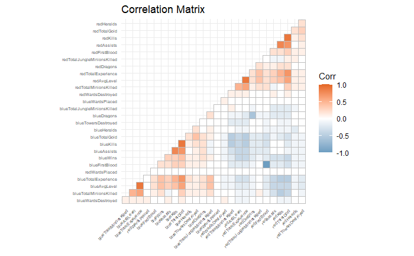

```r
corr_first <- round(cor(df), 1)
ggcorrplot( corr_first,
            hc.order = TRUE,
            type = "lower",
            outline.col = "gray",
            tl.cex = 5,
            colors = c("#6D9EC1", "white", "#E46726")
          ) + ggtitle("Correlation Matrix")
```

```r
df <- df[,!names(df) %in% c("blueAVGLevel", "redAVGLevel")]
```

La columna *redFirstBlood* es la contraparte de *blueFirstBlood* (puesto que si no consigue un equipo la primera sangre la consigue el otro), se suprime la variable del equipo rojo para seguir la misma estructura en todo el *dataset* al tener sólo *blueWins*, que es la variable a predecir (no existe *redWins* en el *dataset* porque precisamente sería la contraparte).

```r
df <- df[,!names(df) %in% c("redFirstBlood")]
```

## Variables correlacionadas restantes

Cabe destacar una correlación natural entre *blueKills* y *blueTotalGold* (y sus contrapartidas *redKills* y *redTotalGold*), puesto que cada *kill* da 300 de oro, pero al haber más formas de conseguir oro en el juego, no es pertinente eliminar ninguna de las dos.

Se analiza la distribución, separando entre equipo rojo y equipo azul por claridad a la hora de mostrar los gráficos.

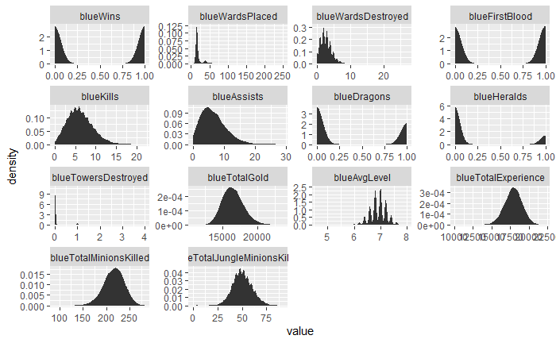

```r
df_sideBlue <- melt(df[1:14])
df_sideRed <- melt(df[15:26])

ggplot(data = df_sideBlue, aes(x = value))+
       stat_density()+
       facet_wrap(~variable, scales = "free")
```

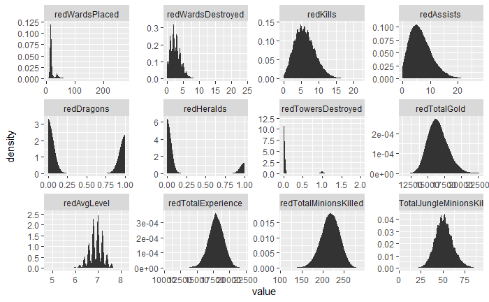

```r
ggplot(data=df_sideRed, aes(x = value))+
       stat_density()+
       facet_wrap(~variable, scales = "free")
```

Se puede ver que las variables tienen una distribución normal cuando se trata de variables no dicotómicas, mientras las dicotómicas (*blueWins*, *blueFirstBlood*, *blueHerlads*, *blueDragons* y sus contrapartes en *red*) cumplen con su definición. Las variables *blueTowersDestroyed*, *blueWardsPlaced* y *blueWardsDestroyed* (y sus contrapartidas en *red*) siguen una distribución logarítmica normal, puesto que los sucesos alejados del eje *Y* son muy improbables.

Los “Dragones” y “Heraldos” son dicotómicas por las características del *dataset*, puesto que no pueden suceder más de 1 vez antes de la marca temporal de los 10min.

Se hacen *boxplots* de los casos anómalos para encontrar *outliers* y decidir si se deben quitar.

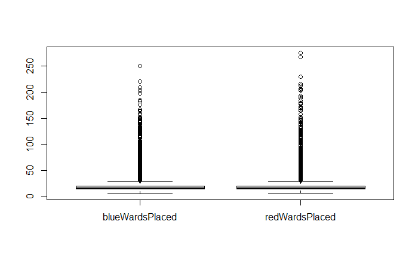

```r
boxplot(df[c("blueWardsPlaced","redWardsPlaced")])
```

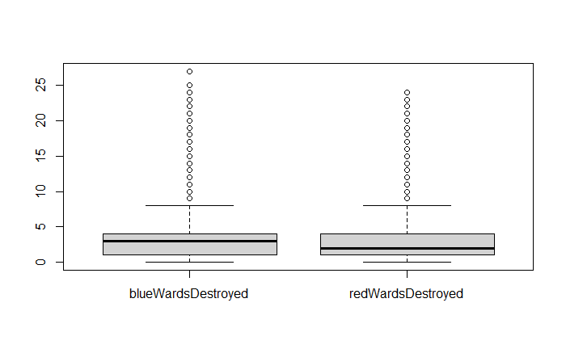

```r
boxplot(df[c("blueWardsDestroyed","redWardsDestroyed")])
```

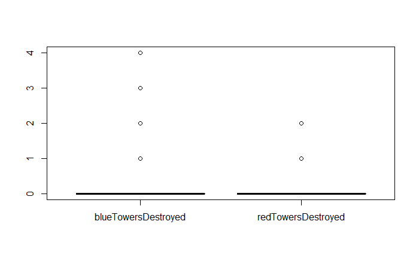

```r
boxplot(df[c("blueTowersDestroyed","redTowersDestroyed")])
```

Se comprueba que son datos plausibles dentro de cómo funciona *League of Legends*, se podría valorar quitarlos si posteriormente perjudicasen al modelo. El caso más preocupante serían las partidas donde se tiran más de 2 torres al minuto 10, pero de momento no se van a sacar del *dataset*.

## Análisis de Componentes Principales

Como continuación del proceso de limpieza y exploración de los datos, se realiza un Análisis de Componentes Principales (PCA). En caso de que fuese necesario, se usará un *dataset* con el PCA en un modelo para compararlo con el modelo escogido.

Para hacer el análisis, se elimina la variable a predecir (*blueWins*).

```r
df_noWins <- df[,-1]
df_Wins <-df$blueWins
```

A continuación se buscan nuevamente correlaciones después de la limpieza de datos

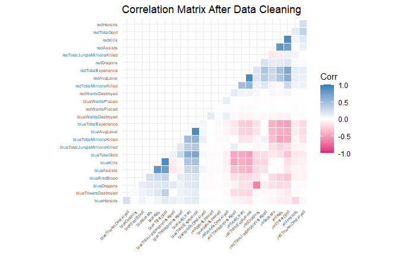

```r
corr_post <- cor(df_noWins)
ggcorrplot( corr_post,
            hc.order = TRUE,
            type = "lower",
            outline.col = "white",
            tl.cex = 5,
            colors = c("#dd1c77", "white", "#2c7fb8")
          )   + ggtitle("Correlation Matrix After Data Cleaning")
```

Se observa una tabla con el comportamiento que se esperaba, con los problemas de colinealidad descritos en el apartado anterior. A continuación, se hace un análisis de componentes principales del *dataset*, normalizándolo.

```r
df_PCA <- prcomp(df_noWins, scale = TRUE)
summary(df_PCA)
```

```
Importance of components:
                          PC1    PC2     PC3     PC4     PC5     PC6    PC7     PC8     PC9    PC10    PC11    PC12    PC13    PC14
Standard deviation     2.4229 1.6922 1.37776 1.24824 1.13916 1.11173 1.0654 1.04926 1.03163 0.96373 0.93028 0.90699 0.87277 0.83705
Proportion of Variance 0.2348 0.1145 0.07593 0.06232 0.05191 0.04944 0.0454 0.04404 0.04257 0.03715 0.03462 0.03291 0.03047 0.02803
Cumulative Proportion  0.2348 0.3494 0.42529 0.48762 0.53952 0.58896 0.6344 0.67840 0.72097 0.75812 0.79274 0.82565 0.85612 0.88414
                          PC15    PC16    PC17    PC18    PC19    PC20    PC21    PC22    PC23    PC24    PC25
Standard deviation     0.82399 0.80664 0.63606 0.57714 0.53651 0.43543 0.37592 0.27932 0.25695 0.18787 0.17631
Proportion of Variance 0.02716 0.02603 0.01618 0.01332 0.01151 0.00758 0.00565 0.00312 0.00264 0.00141 0.00124
Cumulative Proportion  0.91130 0.93733 0.95351 0.96683 0.97835 0.98593 0.99158 0.99470 0.99734 0.99876 1.00000
```

Se puede contemplar en la columna *‘Cummulative Proportion’* que se necesitan muchos componentes para explicar la varianza de los datos, y que a partir del decimotercer componente el porcentaje acumulado es ínfimo. Con la gráfica a continuación, gracias a la función [*fviz_eig()*](https://www.rdocumentation.org/packages/factoextra/versions/1.0.7/topics/eigenvalue) del paquete *factoextra*, se ilustra lo que se acaba de mencionar con las proporciones de varianza acumuladas.

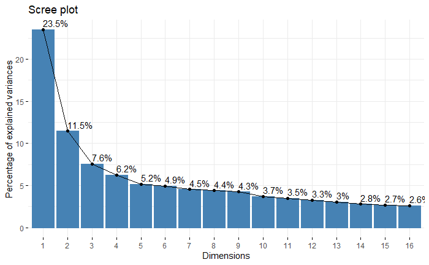

```r
fviz_eig(df_PCA, addlabels = TRUE, ncp = 16)
```

```r
# get_eig(df_PCA)
```

Con el gráfico a continuación se ilustra lo que aportan cada variable a las 13 dimensiones que se han elegido.

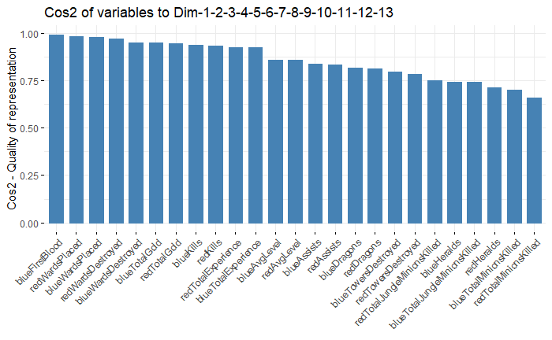

```r
fviz_cos2(df_PCA, choice = "var", axes = 1:13)
```

Se ilustra un biplot (con la función [*fviz_pca_biplot()*](https://www.rdocumentation.org/packages/factoextra/versions/1.0.7/topics/fviz_pca) en específico, la cual mejora en legibilidad) para ver con más claridad la relación entre cos2 con las 2 primeras dimensiones del PCA.

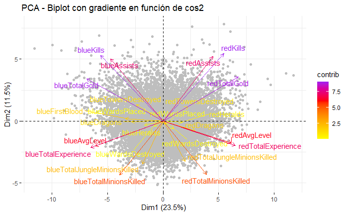

```r
fviz_pca_biplot(df_PCA,
                label = "var",
                repel = TRUE,
                col.ind = "grey",
                col.var = "contrib",
                habillage = "none",
                gradient.cols = c("yellow","orange","red","purple"),
                title = "PCA - Biplot con gradiente en función de cos2"
               )
```

En este gráfico se pueden ver correlaciones ya descritas en la matriz, y con el gradiente las más oscuras son las que más contribuyen a las primeras 2 dimensiones.

```r
head(df_PCA$x)
```

```
            PC1        PC2        PC3         PC4        PC5         PC6        PC7         PC8        PC9       PC10        PC11
[1,] -0.3053428  2.1567567  1.1178173  0.21444693 -0.5359094 -0.92323691  1.3831211 -1.24194915  0.7026742  0.3780208 -0.04857475
[2,]  2.7261154  0.2878242  1.8944058 -0.02591277 -3.2192523  0.46505646 -3.2894528 -0.13815343  1.1038654  0.6920393  1.83972743
[3,]  1.6662611  3.0462708  2.0622460 -1.45422246  1.5285756  1.32991290  0.1037891  1.14285837  0.2936312  0.1174155 -0.68855662
[4,]  0.7831661 -0.5541783  0.1346166  0.11302023  1.8597867  1.21407836 -0.2067669 -0.29879760  0.9745045 -0.6603998  0.51442022
[5,]  0.7727639 -0.6926944 -1.2514918  1.03189628  0.1436694 -0.79728131  0.5527243 -0.08764263  1.9127393 -2.0003779  0.03174135
[6,] -0.4832874 -1.5580756  0.6146685 -1.07015268 -0.2734012 -0.08874767  0.6300268 -0.31863224 -0.1560849 -0.4021418 -1.26219503
           PC12       PC13        PC14        PC15        PC16       PC17       PC18        PC19       PC20         PC21
[1,]  1.0054745 -0.6222564 -0.25539111 -0.05188531  0.50081734 -0.3951641 -0.9990485  0.03643916  0.1374354  0.343231502
[2,] -1.2751722 -1.5797719 -0.12523895  0.32271519  0.14189715 -0.2218126  0.4623759 -0.52339518 -0.1948706 -0.041366531
[3,]  0.7206025 -0.2012029 -0.07697889  0.26308547 -0.22657499  0.1106044  0.6733130  0.02366237 -0.2780962  0.696613942
[4,] -0.8106494 -0.5986431  0.16534940 -0.20516803 -1.35355286 -0.3289388 -1.0977424 -0.51104993  0.9686751  0.231952651
[5,] -1.6959924  0.2298255  0.08855118 -0.20179754  0.83033744  0.4593451 -0.1305312 -0.38918008 -0.2354442  0.156473083
[6,]  0.6134183 -2.1998252 -0.63147397  0.36609852  0.04866242 -0.1298036  0.4897135 -0.03444657  0.2732107 -0.007949892
             PC22        PC23        PC24        PC25
[1,]  0.018795933 -0.16326678 -0.12771061 -0.18524586
[2,] -0.251105801 -0.09882677 -0.11551519 -0.04308494
[3,] -0.003986194  0.17070557  0.34186355  0.08988234
[4,]  0.036859652  0.02523758 -0.06925737  0.04959591
[5,]  0.013415886 -0.17193011 -0.21145800 -0.13175387
[6,]  0.013109423 -0.02668905  0.07445551 -0.03801920
```

## Separación de los datos

Se escoge repartir los datos de forma aleatoria en 2 subsets, uno de entrenamiento y otro para comprobar posteriormente los modelos frente a los datos originales. Dividimos también el *dataset* sin victorias. El *split* se hace un 80-20 para cada uno de los *datasets*. Tranformamos en factores la variable a predecir para garantizar el buen comportamiento de los paquetes de R.

```r
mark <- sample(c ( TRUE , FALSE ), nrow (df), replace = TRUE , prob = c (0.8, 0.2))
train <- df[mark, ]
test <- df[!mark, ]

train_noWins <- df_noWins[mark, ]
test_noWins <- df_noWins[!mark, ]

train_asFactor <- train
train_asFactor$blueWins <- as.factor(train_asFactor$blueWins)

test_asFactor <- test
test_asFactor$blueWins <- as.factor(test_asFactor$blueWins)
```

# Modelos escogidos

En este trabajo se tratan 3 modelos distintos de *Machine Learning*:

1. Regresión Logística
2. Naive Bayes
3. Árbol de Decisión

Posteriormente en el apartado de Métricas se decidirá cuál es el más apto para la resolución del problema.

## Regresión Logística

### Modelo GLM

Se usa la función *glm()* (modelo lineal general) y especificamos *family = “binomial”* para usar un modelo de regresión logística al *dataset*. La variable a predecir es *blueWins*.

```r
model_GLM <- glm( blueWins ~ .,family = "binomial", data = train_asFactor)
summary(model_GLM)
```

```
Call:
glm(formula = blueWins ~ ., family = "binomial", data = train_asFactor)

Deviance Residuals:
    Min       1Q   Median       3Q      Max
-2.6969  -0.8696   0.1199   0.8658   2.7934

Coefficients:
                               Estimate Std. Error z value Pr(>|z|)
(Intercept)                  -1.741e-01  1.381e+00  -0.126 0.899662
blueWardsPlaced              -1.206e-03  1.499e-03  -0.805 0.420917
blueWardsDestroyed           -2.575e-03  1.297e-02  -0.199 0.842637
blueFirstBlood                5.170e-02  5.878e-02   0.880 0.379070
blueKills                    -3.398e-02  3.438e-02  -0.988 0.323034
blueAssists                  -1.256e-02  1.300e-02  -0.966 0.334001
blueDragons                   3.943e-01  7.319e-02   5.388 7.13e-08 ***
blueHeralds                   1.867e-02  7.295e-02   0.256 0.798049
blueTowersDestroyed          -2.846e-01  1.619e-01  -1.758 0.078706 .
blueTotalGold                 5.274e-04  7.804e-05   6.758 1.40e-11 ***
blueAvgLevel                 -1.792e-01  2.017e-01  -0.888 0.374401
blueTotalExperience           2.495e-04  6.657e-05   3.748 0.000178 ***
blueTotalMinionsKilled       -2.913e-03  2.169e-03  -1.343 0.179355
blueTotalJungleMinionsKilled  3.182e-03  3.708e-03   0.858 0.390833
redWardsPlaced               -1.529e-03  1.446e-03  -1.057 0.290360
redWardsDestroyed            -1.350e-03  1.292e-02  -0.104 0.916806
redKills                     -4.033e-04  3.415e-02  -0.012 0.990578
redAssists                    1.741e-02  1.264e-02   1.377 0.168414
redDragons                   -2.826e-01  7.187e-02  -3.933 8.39e-05 ***
redHeralds                   -8.872e-02  7.727e-02  -1.148 0.250842
redTowersDestroyed            3.666e-01  1.680e-01   2.182 0.029108 *
redTotalGold                 -4.602e-04  7.716e-05  -5.964 2.46e-09 ***
redAvgLevel                   1.049e-02  2.023e-01   0.052 0.958637
redTotalExperience           -2.650e-04  6.720e-05  -3.943 8.06e-05 ***
redTotalMinionsKilled         3.958e-03  2.139e-03   1.850 0.064291 .
redTotalJungleMinionsKilled   6.679e-03  3.711e-03   1.800 0.071849 .
---
Signif. codes:  0 ‘***’ 0.001 ‘**’ 0.01 ‘*’ 0.05 ‘.’ 0.1 ‘ ’ 1

(Dispersion parameter for binomial family taken to be 1)

    Null deviance: 11034.9  on 7959  degrees of freedom
Residual deviance:  8382.6  on 7934  degrees of freedom
AIC: 8434.6

Number of Fisher Scoring iterations: 4
```

### Ajuste del Modelo R<sup>2</sup>

Para comprobar cúanto se ajusta el modelo a los datos, se usa R<sup>2</sup> de McFadden:

```r
pscl::pR2(model_GLM)["McFadden"]
```

```
fitting null model for pseudo-r2
 McFadden
0.2403507
```

El R<sup>2</sup> de McFadden de valores entre 0.2 y 0.4 indican que el modelo se ajusta [muy bien a los datos](https://eml.berkeley.edu/~mcfadden/travel.html), puesto que inferior a 0.2 es que el modelo está muy alejado, y más de 0.4 es que el modelo se ajusta de más, dando lugar a *overfitting*.

### Importancia de las variables y VIF

A continuación, sacamos una tabla con la importancia de las variables:

```r
glm_VarImp <- as.data.frame(caret::varImp(model_GLM))
glm_VarImp <- data.frame(VarImp = glm_VarImp$Overall,
                          names = rownames(glm_VarImp))
glm_VarImp <- glm_VarImp[order(glm_VarImp$VarImp,decreasing = T),]
rownames(glm_VarImp) <- NULL
glm_VarImp
```

| VarImp | names |
| --- | --- |
| 6.75804583 | blueTotalGold |
| 5.96398995 | redTotalGold |
| 5.38786020 | blueDragons |
| 3.94261160 | redTotalExperience |
| 3.93290681 | redDragons |
| 3.74834217 | blueTotalExperience |
| 2.18202304 | redTowersDestroyed |
| 1.85015571 | redTotalMinionsKilled |
| 1.80007647 | redTotalJungleMinionsKilled |
| 1.75824302 | blueTowersDestroyed |

[output cut: 15 more lines]

```r
NA
```

Para comprobar si existen problemas de multicolinealidad, se usan los Factores de Inflación de Varianza (VIF).

```r
sort(car::vif(model_GLM), decreasing = TRUE)
```

```
               blueTotalGold                 redTotalGold                    blueKills                     redKills
                   13.886220                    12.854941                    12.264234                    11.199482
         blueTotalExperience           redTotalExperience                 blueAvgLevel                  redAvgLevel
                    6.461874                     6.436347                     4.086301                     3.969657
                 blueAssists                   redAssists       blueTotalMinionsKilled        redTotalMinionsKilled
                    3.354773                     3.209163                     2.855013                     2.805526
 redTotalJungleMinionsKilled blueTotalJungleMinionsKilled                   redDragons                  blueDragons
                    1.883279                     1.811416                     1.764463                     1.716425
         blueTowersDestroyed           redTowersDestroyed               blueFirstBlood                  blueHeralds
                    1.504381                     1.433555                     1.213176                     1.129593
                  redHeralds           blueWardsDestroyed            redWardsDestroyed               redWardsPlaced
                    1.114912                     1.069242                     1.055076                     1.030849
             blueWardsPlaced
                    1.027129
```

Como regla general, los valores de VIF por encima de 5 indican una multicolinealidad severa. Dado que hay varias que superan el 10, es posible que se deba rehacer este modelo haciendo un tratamiento distinto, pero en principio la cadena lógica que nos lleva a elegir estas variables se mantiene, puesto que las que más problemas de colinealidad presentan son las que se han previsto en la Exploración de Datos.

En el apartado de métricas haremos más análisis a este modelo.

## Naive Bayes

En el caso del modelo Naive Bayes, se deben hacer algunas transformaciones a los datos

```r
train_NB <- train_asFactor
test_NB <- test_asFactor

x_train_NB <- train_NB[,-1]
y_train_NB <- train_NB$blueWins
```

### Modelo Naive Bayes

El modelo se basa en el teorema de Bayes, nombrado en honor de Thomas Bayes (1700). este teorema asume que todas las variables son independientes y da la misma importancia a todas las variables. Se usa la librería *caret*.

```r
model_NB = caret::train(x_train_NB, y_train_NB, 'naive_bayes', trControl=trainControl(method='cv',number=10))
model_NB
```

```
Naive Bayes

7960 samples
  25 predictor
   2 classes: '0', '1'

No pre-processing
Resampling: Cross-Validated (10 fold)
Summary of sample sizes: 7163, 7164, 7163, 7164, 7165, 7165, ...
Resampling results across tuning parameters:

  usekernel  Accuracy   Kappa
  FALSE      0.7248796  0.4497802
   TRUE      0.7272693  0.4544962

Tuning parameter 'laplace' was held constant at a value of 0
Tuning parameter 'adjust' was held constant at a value of 1
Accuracy was used to select the optimal model using the largest value.
The final values used for the model were laplace = 0, usekernel = TRUE and adjust = 1.
```

En el apartado métricas se comparará con otros modelos.

### Importancia de las variables

```r
nb_VarImp <- as.data.frame(caret::filterVarImp(model_NB$trainingData, y_train_NB, nonpara = TRUE))
nb_VarImp <- data.frame(VarImp = nb_VarImp$X0, names = rownames(nb_VarImp))
nb_VarImp <- head(nb_VarImp, -1)
nb_VarImp <- nb_VarImp[order(nb_VarImp$VarImp, decreasing = T),]
rownames(nb_VarImp) <- NULL
nb_VarImp
```

| VarImp | names |
| --- | --- |
| 0.7417915 | blueTotalGold |
| 0.7399140 | redTotalGold |
| 0.7294051 | blueTotalExperience |
| 0.7252357 | redTotalExperience |
| 0.6996078 | blueAvgLevel |
| 0.6989901 | redAvgLevel |
| 0.6963795 | redKills |
| 0.6914970 | blueKills |
| 0.6596826 | blueAssists |
| 0.6584104 | redAssists |

[output cut: 15 more lines]

## Árbol de decisión

### Modelo de Árbol de decisión

Se usa la librería [*rpart()*](https://cran.r-project.org/web/packages/rpart/index.html) para hacer un modelo de árbol de decisión.

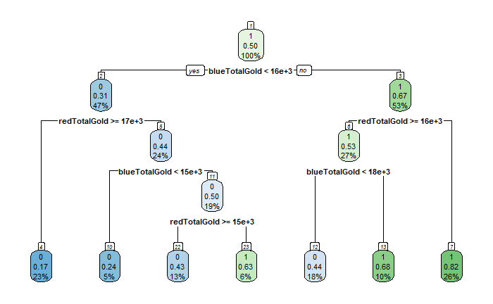

```r
model_BT <- rpart(blueWins~.,
              data = train,
              method = "class")
rpart.plot(model_BT, nn=TRUE)
```

### Reglas de decisión

En la tabla a continuación se muestran las reglas que sigue el árbol a la hora de decidir.

```r
rules_BT <- rpart.rules(model_BT)
row.names(rules_BT) <- NULL
rules_BT
```

| blueWins |  |  |  |  |  |  |  |  |  |  |  |  |
| --- | --- | --- | --- | --- | --- | --- | --- | --- | --- | --- | --- | --- |
| 0.17 | when | blueTotalGold | < | 16276 |  |  | & | redTotalGold | >= |  |  | 16814 |
| 0.24 | when | blueTotalGold | < | 14794 |  |  | & | redTotalGold | < | 16814 |  |  |
| 0.43 | when | blueTotalGold | is | 14794 | to | 16276 | & | redTotalGold | is | 15474 | to | 16814 |
| 0.44 | when | blueTotalGold | is | 16276 | to | 17626 | & | redTotalGold | >= |  |  | 15960 |
| 0.63 | when | blueTotalGold | is | 14794 | to | 16276 | & | redTotalGold | < | 15474 |  |  |
| 0.68 | when | blueTotalGold | >= |  |  | 17626 | & | redTotalGold | >= |  |  | 15960 |
| 0.82 | when | blueTotalGold | >= |  |  | 16276 | & | redTotalGold | < | 15960 |  |  |

En el apartado de métricas haremos más análisis a este modelo.

# Métricas

## Métricas del modelo de Regresión Logística

Matriz de confusión y estadísiticas.

```r
prediction_GLM <- predict.glm(model_GLM, test_asFactor, type = "response")
absolutes_LR <- 1*(prediction_GLM>=0.5)
absolutes_LR <- as.factor(absolutes_LR)
metrics_GLM <- confusionMatrix(test_asFactor$blueWins, absolutes_LR)
metrics_GLM
```

```
Confusion Matrix and Statistics

          Reference
Prediction   0   1
         0 702 275
         1 245 697

               Accuracy : 0.729
                 95% CI : (0.7085, 0.7488)
    No Information Rate : 0.5065
    P-Value [Acc > NIR] : <2e-16

                  Kappa : 0.4582

 Mcnemar's Test P-Value : 0.2035

            Sensitivity : 0.7413
            Specificity : 0.7171
         Pos Pred Value : 0.7185
         Neg Pred Value : 0.7399
             Prevalence : 0.4935
         Detection Rate : 0.3658
   Detection Prevalence : 0.5091
      Balanced Accuracy : 0.7292

       'Positive' Class : 0
```

```r
acc_GLM <- accuracy(test$blueWins, absolutes_LR)
cat("Exactitud del modelo Regresión Logística: ", acc_GLM, "%.\n")
```

```
Exactitud del modelo Regresión Logística:  0.7290255 %.
```

## Métricas del modelo de Naive Bayes

Matriz de confusión y estadísiticas.

```r
prediction_NB <- predict(model_NB, newdata = test_NB )
metrics_NB <- confusionMatrix(prediction_NB, test_NB$blueWins)
metrics_NB
```

```
Confusion Matrix and Statistics

          Reference
Prediction   0   1
         0 665 220
         1 312 722

               Accuracy : 0.7228
                 95% CI : (0.7022, 0.7427)
    No Information Rate : 0.5091
    P-Value [Acc > NIR] : < 2.2e-16

                  Kappa : 0.4463

 Mcnemar's Test P-Value : 7.968e-05

            Sensitivity : 0.6807
            Specificity : 0.7665
         Pos Pred Value : 0.7514
         Neg Pred Value : 0.6983
             Prevalence : 0.5091
         Detection Rate : 0.3465
   Detection Prevalence : 0.4612
      Balanced Accuracy : 0.7236

       'Positive' Class : 0
```

```r
acc_NB <- accuracy(test_NB$blueWins, prediction_NB)
cat("Exactitud del modelo Naive Bayes: ", acc_NB, "%.\n")
```

```
Exactitud del modelo Naive Bayes:  0.7227723 %.
```

## Métricas del modelo de Árbol de decisión

Matriz de confusión y estadísiticas.

```r
prediction_BT <- predict(object = model_BT, test[-1], type = "class")
metrics_BT <- confusionMatrix(table(test$blueWins, prediction_BT))
metrics_BT
```

```
Confusion Matrix and Statistics

   prediction_BT
      0   1
  0 767 210
  1 357 585

               Accuracy : 0.7045
                 95% CI : (0.6836, 0.7249)
    No Information Rate : 0.5857
    P-Value [Acc > NIR] : < 2.2e-16

                  Kappa : 0.4072

 Mcnemar's Test P-Value : 8.71e-10

            Sensitivity : 0.6824
            Specificity : 0.7358
         Pos Pred Value : 0.7851
         Neg Pred Value : 0.6210
             Prevalence : 0.5857
         Detection Rate : 0.3997
   Detection Prevalence : 0.5091
      Balanced Accuracy : 0.7091

       'Positive' Class : 0
```

```r
acc_BT <- accuracy(test$blueWins, prediction_BT)
cat("Exactitud del modelo Árbol de Decisión: ", acc_BT, "%.\n")
```

```
Exactitud del modelo Árbol de Decisión:  0.7045336 %.
```

## Comparación de las métricas

Los 3 modelos tienen una exactitud similar, pero el modelo de Regresión Logística tiene el valor superior al resto. A continuación una tabla que agrupa las 3 exactitudes.

```r
metrics_table <- matrix(c(acc_GLM, acc_NB, acc_BT),ncol = 1, byrow = TRUE)
rownames(metrics_table) <- c("Regresión Logística", "Naive Bayes", "Binary Tree")
colnames(metrics_table) <- c("Exactitud (%)")

metrics_table <- as.table(metrics_table)
metrics_table
```

```
                    Exactitud (%)
Regresión Logística     0.7290255
Naive Bayes             0.7227723
Binary Tree             0.7045336
```

Se utiliza el PCA para hacer un modelo a expensas de encontrar mejores resultados.

# Modelo de Regresión logística con PCA

Gracias a la función pcr() del paquete [*pls*](https://cran.r-project.org/web/packages/pls/pls.pdf) podemos recrear un modelo aplicando Regresión por Componentes Principales, y configurar un modelo acorde.

```r
model_GLMPCA <- pcr( blueWins ~ .,
                     data = train,
                     scale = TRUE,
                     validation = "CV"
                   )
summary(model_GLMPCA)
```

```
Data:   X dimension: 7960 25
    Y dimension: 7960 1
Fit method: svdpc
Number of components considered: 25

VALIDATION: RMSEP
Cross-validated using 10 random segments.
       (Intercept)  1 comps  2 comps  3 comps  4 comps  5 comps  6 comps  7 comps  8 comps  9 comps  10 comps  11 comps  12 comps
CV          0.5001   0.4279   0.4278   0.4278   0.4268   0.4268   0.4268   0.4269    0.427    0.427    0.4271     0.427     0.427
adjCV       0.5001   0.4279   0.4278   0.4278   0.4268   0.4268   0.4268   0.4269    0.427    0.427    0.4270     0.427     0.427
       13 comps  14 comps  15 comps  16 comps  17 comps  18 comps  19 comps  20 comps  21 comps  22 comps  23 comps  24 comps
CV        0.427    0.4269    0.4269    0.4270    0.4269    0.4270    0.4271    0.4271    0.4258    0.4259    0.4259    0.4250
adjCV     0.427    0.4269    0.4269    0.4269    0.4269    0.4269    0.4270    0.4271    0.4258    0.4258    0.4258    0.4249
       25 comps
CV       0.4249
adjCV    0.4248

TRAINING: % variance explained
          1 comps  2 comps  3 comps  4 comps  5 comps  6 comps  7 comps  8 comps  9 comps  10 comps  11 comps  12 comps  13 comps
X           23.58    35.01    42.61    48.85    54.00    58.94    63.46    67.87    72.11     75.82     79.28     82.57     85.62
blueWins    26.81    26.84    26.84    27.20    27.21    27.22    27.22    27.22    27.22     27.23     27.26     27.26     27.30
          14 comps  15 comps  16 comps  17 comps  18 comps  19 comps  20 comps  21 comps  22 comps  23 comps  24 comps  25 comps
X            88.39     91.12     93.73     95.35     96.68     97.83     98.58     99.15     99.47     99.74     99.88     100.0
blueWins     27.34     27.36     27.37     27.40     27.40     27.40     27.40     27.84     27.84     27.85     28.16      28.2
```

Tal y como se mostraba en PCA, hasta el decimotercer componente no se alcanza un 85.6% de explicación de la varianza.

```r
prediction_GLMPCA <- predict(model_GLMPCA, test_asFactor, ncomp = 13, type = "response")
absolutes_LRPCA <- 1*(prediction_GLMPCA>=0.5)
absolutes_LRPCA <- as.factor(absolutes_LRPCA)
metrics_GLMPCA <- confusionMatrix(test_asFactor$blueWins, absolutes_LRPCA)
metrics_GLMPCA
```

```
Confusion Matrix and Statistics

          Reference
Prediction   0   1
         0 696 281
         1 245 697

               Accuracy : 0.7259
                 95% CI : (0.7053, 0.7458)
    No Information Rate : 0.5096
    P-Value [Acc > NIR] : <2e-16

                  Kappa : 0.452

 Mcnemar's Test P-Value : 0.127

            Sensitivity : 0.7396
            Specificity : 0.7127
         Pos Pred Value : 0.7124
         Neg Pred Value : 0.7399
             Prevalence : 0.4904
         Detection Rate : 0.3627
   Detection Prevalence : 0.5091
      Balanced Accuracy : 0.7262

       'Positive' Class : 0
```

Se puede comprobar que no es una mejora significativa respecto a ninguno de los anteriores modelos, e incluso empeora con respecto a su semejante, obteniendo menos exactitud.

```r
acc_GLMPCA <- accuracy(test$blueWins, absolutes_LRPCA)
cat("Exactitud del modelo Regresión Logística con PCA: ", acc_GLMPCA, "%.\n")
```

```
Exactitud del modelo Regresión Logística con PCA:  0.7258989 %.
```

# Modelo escogido: Regresión Logística

En comparación con el resto de los modelos:

```r
metrics_table <- matrix(c(acc_GLM, acc_GLMPCA, acc_NB, acc_BT),ncol = 1, byrow = TRUE)
rownames(metrics_table) <- c("Regresión Logística","Regresión Logística con PCA", "Naive Bayes", "Binary Tree")
colnames(metrics_table) <- c("Exactitud (%)")

metrics_table <- as.table(metrics_table)
metrics_table
```

```
                            Exactitud (%)
Regresión Logística             0.7290255
Regresión Logística con PCA     0.7258989
Naive Bayes                     0.7227723
Binary Tree                     0.7045336
```

## Curva ROC del Modelo Escogido

```r
roc_score = roc(test$blueWins, prediction_GLM)
plot(roc_score, main = "ROC Curve from Logistic Regresion Model")
```

[output not shown]

# Conclusiones

El modelo que más nos conviene sigue siendo el modelo de Regresión Logística, y su curva ROC es buena. Es el más parsimonioso y ninguno de los modelos más complejos tiene mejora significativa. Las variables que más debería priorizar un supuesto *overlay* de *Mobalytics* serían las que vienen dadas por esta tabla de Importancia de Variables en el modelo escogido.

```r
glm_VarImp
```

| VarImp | names |
| --- | --- |
| 6.75804583 | blueTotalGold |
| 5.96398995 | redTotalGold |
| 5.38786020 | blueDragons |
| 3.94261160 | redTotalExperience |
| 3.93290681 | redDragons |
| 3.74834217 | blueTotalExperience |
| 2.18202304 | redTowersDestroyed |
| 1.85015571 | redTotalMinionsKilled |
| 1.80007647 | redTotalJungleMinionsKilled |
| 1.75824302 | blueTowersDestroyed |

[output cut: 15 more lines]

Muchas gracias por leerme.